# Analyzing the 2019 Stack Overflow Developer Survey Results using CRISP-DM

Link to my medium-blog-post: https://medium.com/@robertbemmann/applying-crisp-dm-on-the-2019-stack-overflow-developer-survey-dataset-a651c8da5baf

The cross-industry standard process for data mining or in short CRISP DM is an open standard process model that describes common approaches used by data mining experts. It is the most widely-used analytics model. [source: Wikipedia](https://en.wikipedia.org/wiki/Cross-industry_standard_process_for_data_mining)

In order to demonstrate how CRISP DM works in practice, I'm going to apply the approach to a real-world example. I have chosen the [Stack Overflow Annual Developer Survey dataset from 2019](https://insights.stackoverflow.com/survey).

CRISP DM usually follows a 6-steps approach consisting of:

- **Business Understanding**
- **Data Understanding**
- **Prepare Data**
- **Data Modeling**
- **Evaluate the Results**
- **Deploy**

## 1. Business Understanding

The first part is about asking relevant questions regarding a topic from a business perspective.

The Stack Overflow Developer Survey is an annual survey among employees, specialists or enthusiasts within the IT and Computer Science field conducted by the Q&A site for professional and enthusiast programmers Stack Overflow. For the scope of this project, I am particularly interested in the following questions regarding the dataset of 2019:

**1. Which type of developers has the highest compensation in Europe?**  
**2. Is there a difference in compensation between Europe and the USA?**  
**3. What languages and databases do data professionals work with most? Which ones are in the highest demand according to compensation?**

## 2. Data Understanding

In this step, we need to familiarize with the data and translate the business questions into data questions. Sticking to the example we need to find out which columns of the dataset are relevant/helpful to answer the business questions.

**1. Which type of developers has the highest compensation in Europe?**

- columns `DevType`, `CurrencySymbol` and `ConvertedComp`

**2. Is there a difference in compensation between Europe and the USA?**

- columns `CurrencySymbol` and `ConvertedComp`

**3. What languages and databases do data professionals work with most? Which ones are in the highest demand according to compensation?**

- columns `LanguageWorkedWith`, `DatabaseWorkedWith` and `ConvertedComp`

Additionally, it helps a lot to do the following at the beginning of data exploration:

- Look at the number of rows and columns in the dataset
- Check if there are missing values in any of the rows or columns
- Check if any columns are of different data types than you would expect (ex: numbers showing as strings)
- Build exploratory plots like bar charts, histograms, and scatterplots to better understand the data

```python
import pandas as pd
import numpy as np

import matplotlib.pyplot as plt
import seaborn as sns

from sklearn.linear_model import LinearRegression, LogisticRegression
from sklearn.model_selection import train_test_split
from sklearn.metrics import r2_score, mean_squared_error
```

```python
df = pd.read_csv('developer_survey_2019/survey_results_public.csv')
```

```python
df_schema = pd.read_csv('developer_survey_2019/survey_results_schema.csv')
```

```python
pd.get_option("display.max_rows")
pd.get_option("display.max_columns")
pd.set_option('display.max_colwidth', -1)
pd.set_option('display.max_rows', 84)
pd.set_option('display.max_columns', 84)
```

```python
print("The dataframe has a shape of {}.".format(df.shape))
cols_wo_missing_vals = list(df.columns[df.isna().sum() == 0])
print("There are {} columns with no missing values: {}".format(len(cols_wo_missing_vals), cols_wo_missing_vals))
print("The columns with the highest count of missing values are:")
df.isna().sum().sort_values(ascending=False).head(10)
```

```
The dataframe has a shape of (88883, 85).
There are 3 columns with no missing values: ['Respondent', 'Hobbyist', 'OpenSourcer']
The columns with the highest count of missing values are:
```

```
BlockchainOrg         40708
CodeRevHrs            39093
ConvertedComp         33060
CompTotal             32938
MiscTechWorkedWith    29297
BlockchainIs          28718
PurchaseHow           27775
MgrMoney              27726
MgrIdiot              27724
MgrWant               27651
dtype: int64
```

```python
df_schema
```

|  | Column | QuestionText |
| --- | --- | --- |
| 0 | Respondent | Randomized respondent ID number (not in order of survey response time) |
| 1 | MainBranch | Which of the following options best describes you today? Here, by "developer" we mean "someone who writes code." |
| 2 | Hobbyist | Do you code as a hobby? |
| 3 | OpenSourcer | How often do you contribute to open source? |
| 4 | OpenSource | How do you feel about the quality of open source software (OSS)? |
| 5 | Employment | Which of the following best describes your current employment status? |
| 6 | Country | In which country do you currently reside? |
| 7 | Student | Are you currently enrolled in a formal, degree-granting college or university program? |
| 8 | EdLevel | Which of the following best describes the highest level of formal education that you’ve completed? |
| 9 | UndergradMajor | What was your main or most important field of study? |
| 10 | EduOther | Which of the following types of non-degree education have you used or participated in? Please select all that apply. |
| 11 | OrgSize | Approximately how many people are employed by the company or organization you work for? |
| 12 | DevType | Which of the following describe you? Please select all that apply. |
| 13 | YearsCode | Including any education, how many years have you been coding? |
| 14 | Age1stCode | At what age did you write your first line of code or program? (E.g., webpage, Hello World, Scratch project) |
| 15 | YearsCodePro | How many years have you coded professionally (as a part of your work)? |
| 16 | CareerSat | Overall, how satisfied are you with your career thus far? |
| 17 | JobSat | How satisfied are you with your current job? (If you work multiple jobs, answer for the one you spend the most hours on.) |
| 18 | MgrIdiot | How confident are you that your manager knows what they’re doing? |
| 19 | MgrMoney | Do you believe that you need to be a manager to make more money? |
| 20 | MgrWant | Do you want to become a manager yourself in the future? |
| 21 | JobSeek | Which of the following best describes your current job-seeking status? |
| 22 | LastHireDate | When was the last time that you took a job with a new employer? |
| 23 | LastInt | In your most recent successful job interview (resulting in a job offer), you were asked to... (check all that apply) |
| 24 | FizzBuzz | Have you ever been asked to solve FizzBuzz in an interview? |
| 25 | JobFactors | Imagine that you are deciding between two job offers with the same compensation, benefits, and location. Of the following factors, which 3 are MOST important to you? |
| 26 | ResumeUpdate | Think back to the last time you updated your resumé, CV, or an online profile on a job site. What is the PRIMARY reason that you did so? |
| 27 | CurrencySymbol | Which currency do you use day-to-day? If your answer is complicated, please pick the one you're most comfortable estimating in. |
| 28 | CurrencyDesc | Which currency do you use day-to-day? If your answer is complicated, please pick the one you're most comfortable estimating in. |
| 29 | CompTotal | What is your current total compensation (salary, bonuses, and perks, before taxes and deductions), in `CurrencySymbol`? Please enter a whole number in the box below, without any punctuation. If you ar… |

[output cut: 55 more lines]

85 rows × 2 columns

```python
df.head()
```

|  | Respondent | MainBranch | Hobbyist | OpenSourcer | OpenSource | Employment | Country | Student | EdLevel | UndergradMajor | EduOther | OrgSize | DevType | YearsCode | Age1stCode | YearsCodePro | CareerSat | JobSat | MgrIdiot | MgrMoney | MgrWant | JobSeek | LastHireDate | LastInt | FizzBuzz | JobFactors | ResumeUpdate | CurrencySymbol | CurrencyDesc | … |
| --- | --- | --- | --- | --- | --- | --- | --- | --- | --- | --- | --- | --- | --- | --- | --- | --- | --- | --- | --- | --- | --- | --- | --- | --- | --- | --- | --- | --- | --- | --- |
| 0 | 1 | I am a student who is learning to code | Yes | Never | The quality of OSS and closed source software is about the same | Not employed, and not looking for work | United Kingdom | No | Primary/elementary school | NaN | Taught yourself a new language, framework, or tool without taking a formal course | NaN | NaN | 4 | 10 | NaN | NaN | NaN | NaN | NaN | NaN | NaN | NaN | NaN | NaN | NaN | NaN | NaN | NaN | … |
| 1 | 2 | I am a student who is learning to code | No | Less than once per year | The quality of OSS and closed source software is about the same | Not employed, but looking for work | Bosnia and Herzegovina | Yes, full-time | Secondary school (e.g. American high school, German Realschule or Gymnasium, etc.) | NaN | Taken an online course in programming or software development (e.g. a MOOC) | NaN | Developer, desktop or enterprise applications;Developer, front-end | NaN | 17 | NaN | NaN | NaN | NaN | NaN | NaN | I am actively looking for a job | I've never had a job | NaN | NaN | Financial performance or funding status of the company or organization;Specific department or team I'd be working on;Languages, frameworks, and other technologies I'd be working with | Something else changed (education, award, media, etc.) | NaN | NaN | … |
| 2 | 3 | I am not primarily a developer, but I write code sometimes as part of my work | Yes | Never | The quality of OSS and closed source software is about the same | Employed full-time | Thailand | No | Bachelor’s degree (BA, BS, B.Eng., etc.) | Web development or web design | Taught yourself a new language, framework, or tool without taking a formal course | 100 to 499 employees | Designer;Developer, back-end;Developer, front-end;Developer, full-stack | 3 | 22 | 1 | Slightly satisfied | Slightly satisfied | Not at all confident | Not sure | Not sure | I’m not actively looking, but I am open to new opportunities | 1-2 years ago | Interview with people in peer roles | No | Languages, frameworks, and other technologies I'd be working with;Remote work options;Flex time or a flexible schedule | I was preparing for a job search | THB | Thai baht | … |
| 3 | 4 | I am a developer by profession | No | Never | The quality of OSS and closed source software is about the same | Employed full-time | United States | No | Bachelor’s degree (BA, BS, B.Eng., etc.) | Computer science, computer engineering, or software engineering | Taken an online course in programming or software development (e.g. a MOOC);Received on-the-job training in software development;Taught yourself a new language, framework, or tool without taking a for… | 100 to 499 employees | Developer, full-stack | 3 | 16 | Less than 1 year | Very satisfied | Slightly satisfied | Very confident | No | Not sure | I am not interested in new job opportunities | Less than a year ago | Write code by hand (e.g., on a whiteboard);Interview with people in senior / management roles | No | Languages, frameworks, and other technologies I'd be working with;Office environment or company culture;Opportunities for professional development | I was preparing for a job search | USD | United States dollar | … |
| 4 | 5 | I am a developer by profession | Yes | Once a month or more often | OSS is, on average, of HIGHER quality than proprietary / closed source software | Employed full-time | Ukraine | No | Bachelor’s degree (BA, BS, B.Eng., etc.) | Computer science, computer engineering, or software engineering | Taken an online course in programming or software development (e.g. a MOOC);Received on-the-job training in software development;Taught yourself a new language, framework, or tool without taking a for… | 10,000 or more employees | Academic researcher;Developer, desktop or enterprise applications;Developer, full-stack;Developer, mobile | 16 | 14 | 9 | Very dissatisfied | Slightly dissatisfied | Somewhat confident | Yes | No | I am not interested in new job opportunities | Less than a year ago | Write any code;Write code by hand (e.g., on a whiteboard);Solve a brain-teaser style puzzle;Interview with people in senior / management roles | No | Industry that I'd be working in;Languages, frameworks, and other technologies I'd be working with;Flex time or a flexible schedule | I was preparing for a job search | UAH | Ukrainian hryvnia | … |

5 rows × 85 columns

```python
df.info()
```

```
<class 'pandas.core.frame.DataFrame'>
RangeIndex: 88883 entries, 0 to 88882
Data columns (total 85 columns):
Respondent                88883 non-null int64
MainBranch                88331 non-null object
Hobbyist                  88883 non-null object
OpenSourcer               88883 non-null object
OpenSource                86842 non-null object
Employment                87181 non-null object
Country                   88751 non-null object
Student                   87014 non-null object
EdLevel                   86390 non-null object
UndergradMajor            75614 non-null object
EduOther                  84260 non-null object
OrgSize                   71791 non-null object
DevType                   81335 non-null object
YearsCode                 87938 non-null object
Age1stCode                87634 non-null object
YearsCodePro              74331 non-null object
CareerSat                 72847 non-null object
JobSat                    70988 non-null object
MgrIdiot                  61159 non-null object
MgrMoney                  61157 non-null object
MgrWant                   61232 non-null object
JobSeek                   80555 non-null object
LastHireDate              79854 non-null object
LastInt                   67155 non-null object
FizzBuzz                  71344 non-null object
JobFactors                79371 non-null object
ResumeUpdate              77877 non-null object
CurrencySymbol            71392 non-null object
CurrencyDesc              71392 non-null object
CompTotal                 55945 non-null float64
CompFreq                  63268 non-null object
ConvertedComp             55823 non-null float64
WorkWeekHrs               64503 non-null float64
WorkPlan                  68914 non-null object
WorkChallenge             68141 non-null object
WorkRemote                70284 non-null object
WorkLoc                   70055 non-null object
```

[output cut: 35 more lines]

```
SOJobs                    88066 non-null object
EntTeams                  87841 non-null object
SOComm                    88131 non-null object
WelcomeChange             85855 non-null object
SONewContent              69560 non-null object
Age                       79210 non-null float64
Gender                    85406 non-null object
Trans                     83607 non-null object
Sexuality                 76147 non-null object
Ethnicity                 76668 non-null object
Dependents                83059 non-null object
SurveyLength              86984 non-null object
SurveyEase                87081 non-null object
dtypes: float64(5), int64(1), object(79)
memory usage: 57.6+ MB
```

## 3. Prepare Data

**1. Which type of developers has the highest compensation in Europe?**  
**2. Is there a difference in compensation between Europe and the USA?**

In order to get answers for question 1 and 2, we need to do several cleaning and preparation steps.

We need to get a list of unique `DevType`'s first. Also we are not really interested in `Students` and want to filter out the nan values. As participants can select multiple `DevType`'s, we need to clean the data up.

```python
def get_unique_values_list(column_name):
    '''
    INPUT:
    column_name - a string which matches a column name of the SO survey dataframe

    OUTPUT:
    output_list - a list of strings which contains all unique values of the input column

    Description:
    The function takes the name of a column of the SO survey dataframe and creates a Series
    (datatype string) with unique values from the dataframe subset of the respective column.
    Then the unique values row values are splitted by ';' and each piece is added to a list
    in case it is not already part of the list. Eventually, the list is returned.
    '''
    all_values_list = df[column_name].astype(str).unique()
    output_list = []
    for row in all_values_list:
        for entry in row.split(';'):
            if entry in output_list:
                True
            else:
                output_list.append(entry)
    return output_list

all_dev_types_list = get_unique_values_list('DevType')
print(all_dev_types_list)
```

```
['nan', 'Developer, desktop or enterprise applications', 'Developer, front-end', 'Designer', 'Developer, back-end', 'Developer, full-stack', 'Academic researcher', 'Developer, mobile', 'Data or business analyst', 'Data scientist or machine learning specialist', 'Database administrator', 'Engineer, d…
```

```python
df['DevType'][(df['CurrencySymbol'] == 'EUR') & (df['DevType'].astype(str) == 'nan')].count() + \
df['DevType'][(df['CurrencySymbol'] == 'EUR') & (df['DevType'].astype(str) == 'Student')].count()
```

```
19
```

```python
all_dev_types_list.remove('Student')
all_dev_types_list.remove('nan')
print(all_dev_types_list)
```

```
['Developer, desktop or enterprise applications', 'Developer, front-end', 'Designer', 'Developer, back-end', 'Developer, full-stack', 'Academic researcher', 'Developer, mobile', 'Data or business analyst', 'Data scientist or machine learning specialist', 'Database administrator', 'Engineer, data', '…
```

In this step, we add `dev_type` columns for each `DevType` to the dataframe and insert the value 1 if the participant selected the respective `DevType` (0 if not selected).

```python
map_dev_type = lambda x: 1 if dev_type in x else 0

for dev_type in all_dev_types_list:
    df['dev_type_'+dev_type] = df['DevType'].astype(str).apply(map_dev_type)
```

```python
df.columns
```

```
Index(['Respondent', 'MainBranch', 'Hobbyist', 'OpenSourcer', 'OpenSource',
       'Employment', 'Country', 'Student', 'EdLevel', 'UndergradMajor',
       ...
       'dev_type_DevOps specialist', 'dev_type_Developer, game or graphics',
       'dev_type_Educator', 'dev_type_Engineering manager',
       'dev_type_Senior executive/VP', 'dev_type_System administrator',
       'dev_type_Developer, embedded applications or devices',
       'dev_type_Product manager', 'dev_type_Scientist',
       'dev_type_Marketing or sales professional'],
      dtype='object', length=108)
```

We might want to take another dimension into account as well as the experience usually impacts the skills or the gathered knowledge of a developer: the years of professional coding or `YearsCodePro`. This column initially was of string dtype and needs to be changed to numeric so that we can use it better for graphs/visualizations.

```python
print(df['YearsCodePro'].unique())

convert_years_code = lambda x: '0.5' if x == 'Less than 1 year' else ('55' if x == 'More than 50 years' else x)
df['YearsCodePro'] = df['YearsCodePro'].apply(convert_years_code).astype(float)

print(df['YearsCodePro'].unique())
```

```
[nan '1' 'Less than 1 year' '9' '3' '4' '10' '8' '2' '13' '18' '5' '14'
 '22' '23' '19' '35' '20' '25' '7' '15' '27' '6' '48' '12' '31' '11' '17'
 '16' '21' '29' '30' '26' '33' '28' '37' '40' '34' '24' '39' '38' '36'
 '32' '41' '45' '43' 'More than 50 years' '44' '42' '46' '49' '50' '47']
[ nan  1.   0.5  9.   3.   4.  10.   8.   2.  13.  18.   5.  14.  22.
 23.  19.  35.  20.  25.   7.  15.  27.   6.  48.  12.  31.  11.  17.
 16.  21.  29.  30.  26.  33.  28.  37.  40.  34.  24.  39.  38.  36.
 32.  41.  45.  43.  55.  44.  42.  46.  49.  50.  47. ]
```

The Total Converted Compensation (in USD) follows a right skewed distribution, with a few big outliers. Therefore, it might make sense to use the median instead of the mean for this metric.

```
count    5.582300e+04
mean     1.271107e+05
std      2.841523e+05
min      0.000000e+00
25%      2.577750e+04
50%      5.728700e+04
75%      1.000000e+05
max      2.000000e+06
Name: ConvertedComp, dtype: float64
```

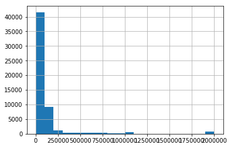

```python
print(df['ConvertedComp'].describe())
df['ConvertedComp'].hist(bins=20, range=(0,2000000));
```

Finally, we create a dataframe with all the relevant metrics and also write a function as we might want to apply the same steps to an input dataframe with a different filter to answer question 2. In order to test everything, we apply the function and the graph to the full dataset.

```python
def create_dev_type_metrics_df(input_df):
    '''
    INPUT:
    input_df - the name of a dataframe (can be subset) of the SO survey data

    OUTPUT:
    df_dev_type_metrics - dataframe with aggregated metrics per developer type
    for reporting purposes
    total_count - the total count of all dev_type occurences

    Description:
    The function takes a dataframe of the SO survey raw data (or a subset) and
    returns after a few transformations a dataframe with aggregated metrics
    per developer type like median of compensation, avg. years of professional
    coding experience and the count per developer type. Furthermore an integer
    number of the total count is returned.
    '''
    list_dev_type = []
    list_median_comp = []
    list_avg_prf_exp = []
    list_count_dev_type = []

    for dev_type in all_dev_types_list:
        list_dev_type.append(dev_type)
        list_median_comp.append(input_df['ConvertedComp'][input_df['dev_type_'+dev_type] == 1].median())
        list_avg_prf_exp.append(input_df['YearsCodePro'][input_df['dev_type_'+dev_type] == 1].astype(float).mean(skipna=True))
        list_count_dev_type.append(input_df['dev_type_'+dev_type][input_df['dev_type_'+dev_type] == 1].count())

    df_dev_type_metrics = pd.DataFrame({'dev_type': list_dev_type,
                                        'compensation_median': list_median_comp,
                                        'prf_exp_mean': list_avg_prf_exp,
                                        'devtype_count': list_count_dev_type})

    total_count = df_dev_type_metrics['devtype_count'].sum()

    return df_dev_type_metrics, total_count
```

```python
df_dev_type_metrics_total, total_count = create_dev_type_metrics_df(df)
df_dev_type_metrics_total.head()
```

|  | dev_type | compensation_median | prf_exp_mean | devtype_count |
| --- | --- | --- | --- | --- |
| 0 | Developer, desktop or enterprise applications | 56142.0 | 9.938877 | 17316 |
| 1 | Developer, front-end | 51559.0 | 7.868190 | 26649 |
| 2 | Designer | 50868.0 | 9.138624 | 9182 |
| 3 | Developer, back-end | 55680.0 | 8.503672 | 40665 |
| 4 | Developer, full-stack | 57425.5 | 8.280776 | 42222 |

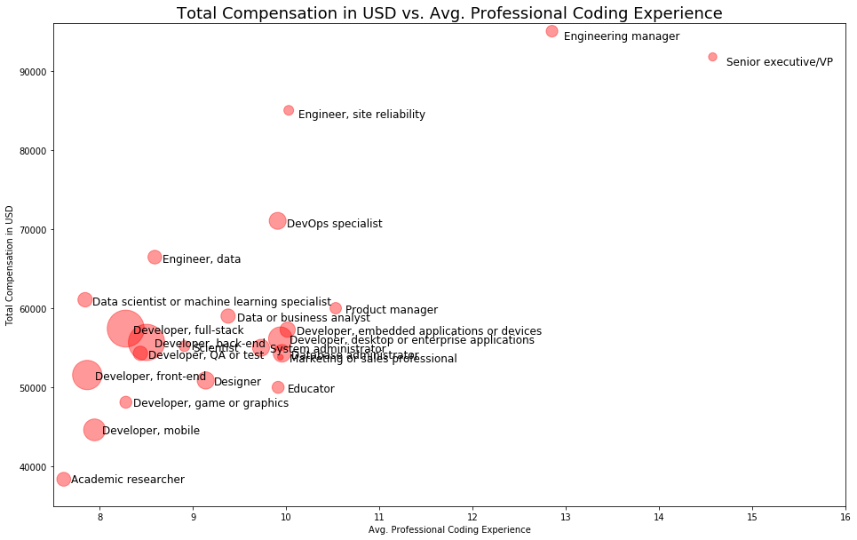

```python
x = df_dev_type_metrics_total['prf_exp_mean']
y = df_dev_type_metrics_total['compensation_median']

scale = df_dev_type_metrics_total['devtype_count']/total_count*10000
c = df_dev_type_metrics_total['dev_type']

xmin, xmax, ymin, ymax= 7.5, 16, 35000, 96000

plt.figure(figsize=(16,10))
plt.scatter(x, y, color='r', s=scale, alpha=0.4)
plt.xlim(xmin, xmax)
plt.ylim(ymin, ymax)
plt.title("Total Compensation in USD vs. Avg. Professional Coding Experience", fontsize=18)
plt.xlabel("Avg. Professional Coding Experience")
plt.ylabel("Total Compensation in USD")

for i, txt in enumerate(c):
    plt.text(1.01*x[i], 0.99*y[i], s=txt, fontsize=12)

plt.show()
```

**3. What languages and databases do data professionals work with most? Which ones are in the highest demand according to compensation?**

Now, we'll prepare the data for question 3. I defined data professionals as

```
['Data or business analyst', 'Data scientist or machine learning specialist', 'Database administrator', 'Engineer, data']
```

```python
data_guys = ['Data or business analyst', 'Data scientist or machine learning specialist',
             'Database administrator', 'Engineer, data']
```

```python
# get unique values with previously written function
all_languages_list = get_unique_values_list('LanguageWorkedWith')
all_dbs_list = get_unique_values_list('DatabaseWorkedWith')

# check output
print('Before cleansing:')
print(all_languages_list)
print(all_dbs_list)

# clean lists
all_languages_list.remove('Other(s):')
all_languages_list.remove('nan')
all_dbs_list.remove('Other(s):')
all_dbs_list.remove('nan')

# check output
print('\nAfter cleansing:')
print(all_languages_list)
print(all_dbs_list)
```

```
Before cleansing:
['HTML/CSS', 'Java', 'JavaScript', 'Python', 'C++', 'C', 'C#', 'SQL', 'VBA', 'R', 'Bash/Shell/PowerShell', 'Ruby', 'Rust', 'TypeScript', 'WebAssembly', 'Other(s):', 'Go', 'PHP', 'Assembly', 'Kotlin', 'Swift', 'nan', 'Objective-C', 'Elixir', 'Erlang', 'Clojure', 'F#', 'Scala', 'Dart']
['SQLite', 'nan', 'PostgreSQL', 'MySQL', 'Couchbase', 'MongoDB', 'Oracle', 'Cassandra', 'Elasticsearch', 'Redis', 'DynamoDB', 'Microsoft SQL Server', 'Firebase', 'MariaDB', 'Other(s):']

After cleansing:
['HTML/CSS', 'Java', 'JavaScript', 'Python', 'C++', 'C', 'C#', 'SQL', 'VBA', 'R', 'Bash/Shell/PowerShell', 'Ruby', 'Rust', 'TypeScript', 'WebAssembly', 'Go', 'PHP', 'Assembly', 'Kotlin', 'Swift', 'Objective-C', 'Elixir', 'Erlang', 'Clojure', 'F#', 'Scala', 'Dart']
['SQLite', 'PostgreSQL', 'MySQL', 'Couchbase', 'MongoDB', 'Oracle', 'Cassandra', 'Elasticsearch', 'Redis', 'DynamoDB', 'Microsoft SQL Server', 'Firebase', 'MariaDB']
```

```python
# prepare columns
df['LanguageWorkedWith'] = df['LanguageWorkedWith'].astype(str)
df['DatabaseWorkedWith'] = df['DatabaseWorkedWith'].astype(str)

# add colums for languages and databases
map_language = lambda x: 1 if language in x else 0
for language in all_languages_list:
    df['language_'+language] = df['LanguageWorkedWith'].apply(map_language)

map_db = lambda x: 1 if db in x else 0
for db in all_dbs_list:
    df['db_'+db] = df['DatabaseWorkedWith'].apply(map_db)
```

```python
strings=['data','Data']

#list_dev_type = []
list_language_db = []
list_language_db_count = []
list_language_db_comp_median = []

#for dev_type in data_guys:
for language in all_languages_list:
    list_language_db.append(language)
    list_language_db_count.append(df['dev_type_'+dev_type][(df['language_'+language] == 1) &
                                                           (df['DevType'].str.contains('|'.join(strings),regex=True))]\
                                                           .count())
    list_language_db_comp_median.append(df['ConvertedComp'][(df['language_'+language] == 1) &
                                                            (df['DevType'].str.contains('|'.join(strings),regex=True))]\
                                                            .median())

#for dev_type in data_guys:
for db in all_dbs_list:
        list_language_db.append(db)
        list_language_db_count.append(df['dev_type_'+dev_type][(df['db_'+db] == 1) &
                                                               (df['DevType'].str.contains('|'.join(strings),regex=True))]\
                                                               .count())
        list_language_db_comp_median.append(df['ConvertedComp'][(df['db_'+db] == 1) &
                                                               (df['DevType'].str.contains('|'.join(strings),regex=True))]\
                                                               .median())

df_data_guys_metrics = pd.DataFrame({'language_db': list_language_db,
                                     'language_db_count': list_language_db_count,
                                     'language_db_comp_median':list_language_db_comp_median})
df_data_guys_metrics#.head(5)
```

|  | language_db | language_db_count | language_db_comp_median |
| --- | --- | --- | --- |
| 0 | HTML/CSS | 12396 | 54996.0 |
| 1 | Java | 14801 | 55610.0 |
| 2 | JavaScript | 12800 | 55238.5 |
| 3 | Python | 10881 | 61071.0 |
| 4 | C++ | 4810 | 50000.0 |
| 5 | C | 15511 | 55971.0 |
| 6 | C# | 6214 | 57287.0 |
| 7 | SQL | 13746 | 58881.0 |
| 8 | VBA | 2035 | 59508.0 |
| 9 | R | 4490 | 68748.0 |
| 10 | Bash/Shell/PowerShell | 8570 | 67599.0 |
| 11 | Ruby | 1478 | 75315.0 |
| 12 | Rust | 600 | 68705.0 |
| 13 | TypeScript | 3501 | 58373.0 |
| 14 | WebAssembly | 295 | 55848.0 |
| 15 | Go | 1773 | 74748.0 |
| 16 | PHP | 5961 | 40440.0 |
| 17 | Assembly | 1561 | 43538.0 |
| 18 | Kotlin | 936 | 50231.0 |
| 19 | Swift | 963 | 60000.0 |
| 20 | Objective-C | 785 | 65881.0 |
| 21 | Elixir | 310 | 72522.0 |
| 22 | Erlang | 243 | 69816.0 |
| 23 | Clojure | 323 | 90000.0 |
| 24 | F# | 248 | 70658.0 |
| 25 | Scala | 1282 | 80155.0 |
| 26 | Dart | 356 | 40979.0 |
| 27 | SQLite | 6272 | 53647.0 |
| 28 | PostgreSQL | 6984 | 60496.0 |
| 29 | MySQL | 10335 | 48120.0 |
| 30 | Couchbase | 384 | 59579.0 |
| 31 | MongoDB | 4706 | 52293.5 |
| 32 | Oracle | 3414 | 50693.0 |
| 33 | Cassandra | 868 | 74047.0 |
| 34 | Elasticsearch | 2996 | 71803.0 |
| 35 | Redis | 3538 | 68745.0 |
| 36 | DynamoDB | 1204 | 85236.0 |
| 37 | Microsoft SQL Server | 7195 | 60000.0 |
| 38 | Firebase | 1925 | 38105.0 |
| 39 | MariaDB | 3738 | 45830.0 |

```python
# check if filter condition is correct
df['Respondent'][((df['dev_type_Engineer, data']==1) |
                (df['dev_type_Data or business analyst']==1) |
                (df['dev_type_Data scientist or machine learning specialist']==1) |
                (df['dev_type_Database administrator']==1)) &
                (df['db_MySQL']==1)].count() == \
df['Respondent'][(df['DevType'].str.contains('|'.join(strings),regex=True)) &
                (df['db_MySQL']==1)].count()
```

```
True
```

We can now use this dataframe for plotting the data for all data professionals.

```python
def plots_for_data_professionals(job):
    '''
    INPUT:
    job - a string of a data professional job: ['Data or business analyst',
    'Data scientist or machine learning specialist', 'Database administrator',
    'Engineer, data']

    OUTPUT:
    df_data_guys_metrics - dataframe with aggregated metrics per database
    system or programming language for reporting purposes

    Description:
    The function takes a string of a data professional job and returns after
    a few transformations a dataframe with aggregated metrics  of a subset
    of the SO survey raw dataframe per database system or programming language
    like median of compensation and the count.
    '''
    list_language_db = []
    list_language_db_count = []
    list_language_db_comp_median = []

    for language in all_languages_list:
        list_language_db.append(language)
        list_language_db_count.append(df['dev_type_'+dev_type][(df['language_'+language] == 1) &
                                                           (df['dev_type_'+job]==1)]\
                                                           .count())
        list_language_db_comp_median.append(df['ConvertedComp'][(df['language_'+language] == 1) &
                                                            (df['dev_type_'+job]==1)]\
                                                            .median())

    #for dev_type in data_guys:
    for db in all_dbs_list:
        list_language_db.append(db)
        list_language_db_count.append(df['dev_type_'+dev_type][(df['db_'+db] == 1) &
                                                               (df['dev_type_'+job]==1)]\
                                                               .count())
        list_language_db_comp_median.append(df['ConvertedComp'][(df['db_'+db] == 1) &
                                                               (df['dev_type_'+job]==1)]\
                                                               .median())

    df_data_guys_metrics = pd.DataFrame({'language_db': list_language_db,
                                     'language_db_count': list_language_db_count,
                                     'language_db_comp_median':list_language_db_comp_median})
    # plot dbs used
    df_data_guys_metrics[(df_data_guys_metrics['language_db'].isin(all_dbs_list))].\
                            sort_values('language_db_count', ascending=False).\
                            plot(x='language_db', y='language_db_count', kind='barh',
                                 figsize=(10,6), color='b', alpha=0.4, title='Use of database systems for '+job);
    plt.xlabel("Frequency");
    plt.ylabel("Database");

    # plot languages used
    df_data_guys_metrics[(df_data_guys_metrics['language_db'].isin(all_languages_list))].\
                            sort_values('language_db_count', ascending=False).\
                            plot(x='language_db', y='language_db_count', kind='barh',
                                 figsize=(10,6), color='b', alpha=0.4, title='Use of programming languages for '+job);
    plt.xlabel("Frequency");
    plt.ylabel("Programming Language");

    return df_data_guys_metrics
```

Furthermore, we can also use this function to plot some stats for a specific data professional.

## 5. Evaluate the results

We skip step 4 for now, as data modeling or machine learning is not really needed to answer our questions. Let's start by splitting the full dataset in a USD-currency and a EUR-currency dataframe

```python
df_eu = df[df['CurrencySymbol'] == 'EUR']
df_dev_type_metrics_eu, total_count_eu = create_dev_type_metrics_df(df_eu)

df_us = df[df['CurrencySymbol'] == 'USD']
df_dev_type_metrics_us, total_count_us = create_dev_type_metrics_df(df_us)

df_dev_type_metrics_eu.head()
```

|  | dev_type | compensation_median | prf_exp_mean | devtype_count |
| --- | --- | --- | --- | --- |
| 0 | Developer, desktop or enterprise applications | 50413.0 | 9.690885 | 3448 |
| 1 | Developer, front-end | 46517.0 | 8.009411 | 4902 |
| 2 | Designer | 43538.0 | 9.191994 | 1362 |
| 3 | Developer, back-end | 51550.0 | 8.646028 | 7930 |
| 4 | Developer, full-stack | 49267.0 | 8.461668 | 8025 |

```python
df_dev_type_metrics_us.head()
```

|  | dev_type | compensation_median | prf_exp_mean | devtype_count |
| --- | --- | --- | --- | --- |
| 0 | Developer, desktop or enterprise applications | 105000.0 | 12.047933 | 4106 |
| 1 | Developer, front-end | 98000.0 | 9.482508 | 6353 |
| 2 | Designer | 91000.0 | 11.179625 | 2255 |
| 3 | Developer, back-end | 110000.0 | 10.296386 | 9307 |
| 4 | Developer, full-stack | 104165.0 | 9.613713 | 11021 |

**1. Which type of developers have the highest compensation in Europe?**

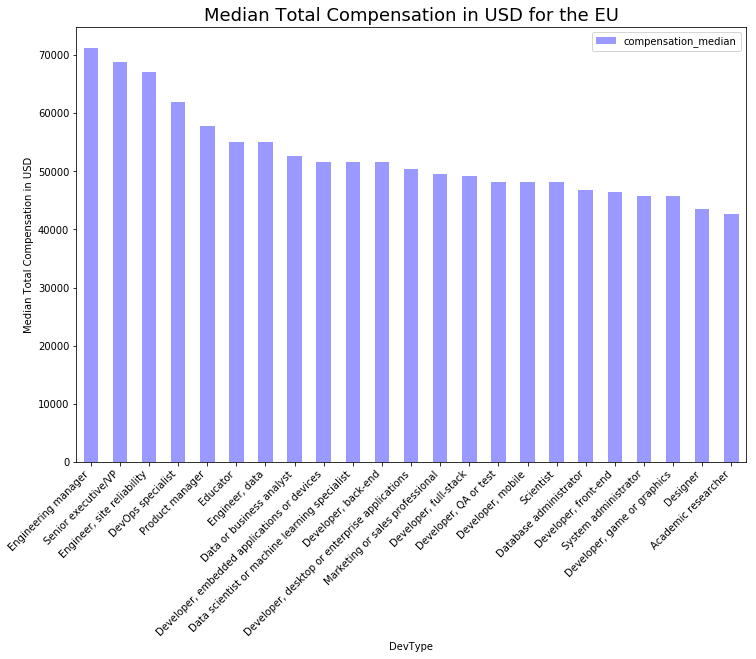

```python
df_dev_type_metrics_eu.sort_values('compensation_median', ascending=False).plot(y='compensation_median',
                                                                               x='dev_type',
                                                                               kind='bar',
                                                                               figsize=(12,8),
                                                                               color='blue',
                                                                               alpha=0.4);
plt.xticks(rotation=45, ha='right', va='top');
plt.title("Median Total Compensation in USD for the EU", fontsize=18);
plt.xlabel("DevType");
plt.ylabel("Median Total Compensation in USD");
```

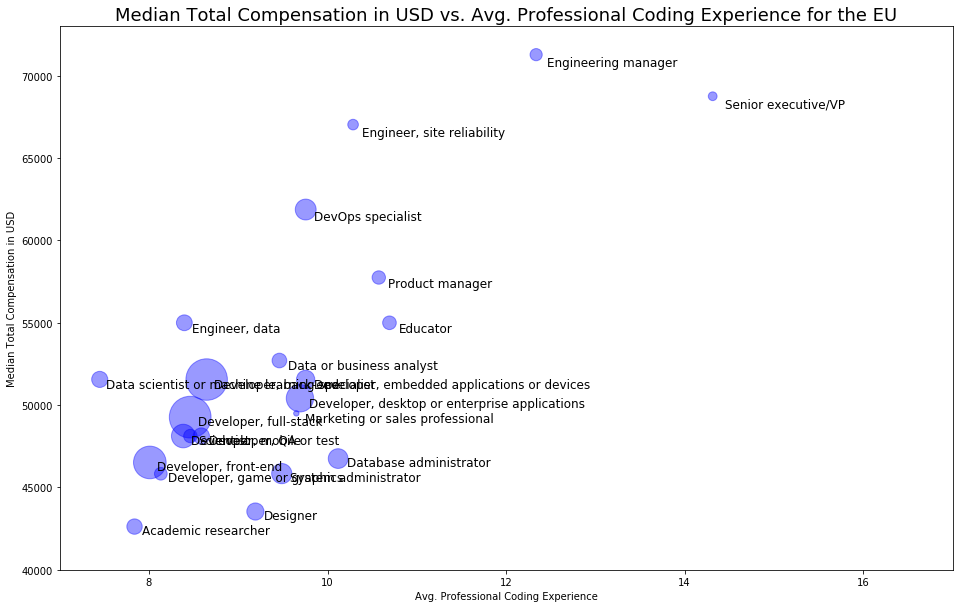

```python
x_eu =      df_dev_type_metrics_eu['prf_exp_mean']
y_eu =      df_dev_type_metrics_eu['compensation_median']
scale_eu =  df_dev_type_metrics_eu['devtype_count']/total_count_eu*10000
c_eu =      df_dev_type_metrics_eu['dev_type']

xmin, xmax, ymin, ymax= 7, 17, 40000, 73000

plt.figure(figsize=(16,10))
plt.scatter(x_eu, y_eu, color='b', s=scale_eu, alpha=0.4)
plt.xlim(xmin, xmax)
plt.ylim(ymin, ymax)
plt.title("Median Total Compensation in USD vs. Avg. Professional Coding Experience for the EU", fontsize=18)
plt.xlabel("Avg. Professional Coding Experience")
plt.ylabel("Median Total Compensation in USD")

for i, txt in enumerate(c_eu):
    plt.text(1.01*x_eu[i], 0.99*y_eu[i], s=txt, fontsize=12)
plt.show()
```

**2. Is there a difference in compensation between Europe and the USA?**

```python
df_helper = df_dev_type_metrics_eu[['dev_type','compensation_median']].copy(deep=True)
df_helper['compensation_median_us'] = df_dev_type_metrics_us['compensation_median']
df_helper.head(2)
```

|  | dev_type | compensation_median | compensation_median_us |
| --- | --- | --- | --- |
| 0 | Developer, desktop or enterprise applications | 50413.0 | 105000.0 |
| 1 | Developer, front-end | 46517.0 | 98000.0 |

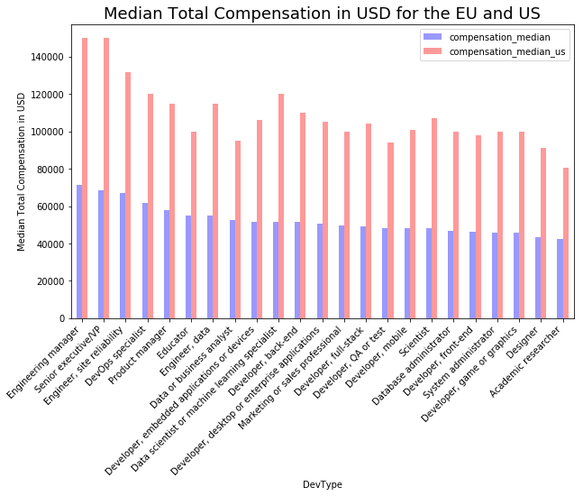

```python
df_helper.sort_values('compensation_median', ascending=False).plot(x='dev_type',
                                                                   kind='bar',
                                                                   figsize=(10,6),
                                                                   color=['b','r'],
                                                                   alpha=0.4);
plt.xticks(rotation=45, ha='right', va='top');
plt.title("Median Total Compensation in USD for the EU and US", fontsize=18);
plt.xlabel("DevType");
plt.ylabel("Median Total Compensation in USD");
```

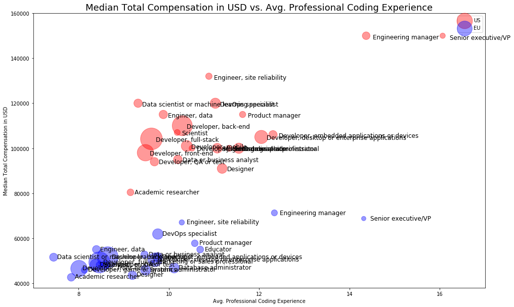

```python
x_us =      df_dev_type_metrics_us['prf_exp_mean']
y_us =      df_dev_type_metrics_us['compensation_median']
scale_us =  df_dev_type_metrics_us['devtype_count']/total_count_us*10000
c_us =      df_dev_type_metrics_us['dev_type']

x_eu =      df_dev_type_metrics_eu['prf_exp_mean']
y_eu =      df_dev_type_metrics_eu['compensation_median']
scale_eu =  df_dev_type_metrics_eu['devtype_count']/total_count_eu*10000
c_eu =      df_dev_type_metrics_eu['dev_type']

xmin, xmax, ymin, ymax= 7, 17, 38000, 160000

plt.figure(figsize=(16,10)) #
plt.scatter(x_us, y_us, color='r', s=scale_us, alpha=0.4)
plt.scatter(x_eu, y_eu, color='b', s=scale_eu, alpha=0.4)
plt.xlim(xmin, xmax)
plt.ylim(ymin, ymax)
plt.title("Median Total Compensation in USD vs. Avg. Professional Coding Experience", fontsize=18)
plt.xlabel("Avg. Professional Coding Experience")
plt.ylabel("Median Total Compensation in USD")

for i, txt in enumerate(c_us):
    plt.text(1.01*x_us[i], 0.99*y_us[i], s=txt, fontsize=12)

for i, txt in enumerate(c_eu):
    plt.text(1.01*x_eu[i], 0.99*y_eu[i], s=txt, fontsize=12)

plt.legend(['US','EU'])

plt.show()
```

```python
all_dev_types_list
```

```
['Developer, desktop or enterprise applications',
 'Developer, front-end',
 'Designer',
 'Developer, back-end',
 'Developer, full-stack',
 'Academic researcher',
 'Developer, mobile',
 'Data or business analyst',
 'Data scientist or machine learning specialist',
 'Database administrator',
 'Engineer, data',
 'Engineer, site reliability',
 'Developer, QA or test',
 'DevOps specialist',
 'Developer, game or graphics',
 'Educator',
 'Engineering manager',
 'Senior executive/VP',
 'System administrator',
 'Developer, embedded applications or devices',
 'Product manager',
 'Scientist',
 'Marketing or sales professional']
```

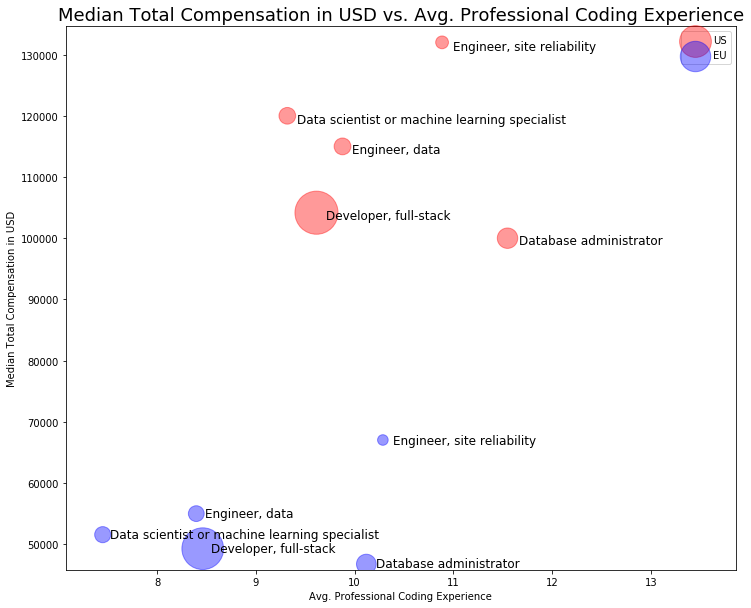

```python
select = ['Engineer, data', 'Database administrator',
          'Data scientist or machine learning specialist','Engineer, site reliability',
         'Developer, full-stack']
#all_dev_types_list

x_us =      df_dev_type_metrics_us['prf_exp_mean'][df_dev_type_metrics_us['dev_type'].isin(select)].values
y_us =      df_dev_type_metrics_us['compensation_median'][df_dev_type_metrics_us['dev_type'].isin(select)].values
scale_us =  df_dev_type_metrics_us['devtype_count'][df_dev_type_metrics_us['dev_type'].isin(select)]/total_count_us*10000
label_us =      df_dev_type_metrics_us['dev_type'][df_dev_type_metrics_us['dev_type'].isin(select)].values

x_eu =      df_dev_type_metrics_eu['prf_exp_mean'][df_dev_type_metrics_us['dev_type'].isin(select)].values
y_eu =      df_dev_type_metrics_eu['compensation_median'][df_dev_type_metrics_us['dev_type'].isin(select)].values
scale_eu =  df_dev_type_metrics_eu['devtype_count'][df_dev_type_metrics_us['dev_type'].isin(select)]/total_count_eu*10000
label_eu =  df_dev_type_metrics_eu['dev_type'][df_dev_type_metrics_us['dev_type'].isin(select)].values

xmin, xmax, ymin, ymax= min(min(x_us),min(x_eu)), max(max(x_us),max(x_eu)), min(min(y_us),min(y_eu)), max(max(y_us),max(y_eu))

plt.figure(figsize=(12,10))
plt.scatter(x_us, y_us, color='r', s=scale_us, alpha=0.4)
plt.scatter(x_eu, y_eu, color='b', s=scale_eu, alpha=0.4)

plt.xlim(0.95*xmin, 1.20*xmax)
plt.ylim(0.98*ymin, 1.02*ymax)

plt.title("Median Total Compensation in USD vs. Avg. Professional Coding Experience", fontsize=18)
plt.xlabel("Avg. Professional Coding Experience")
plt.ylabel("Median Total Compensation in USD")

for i, txt in enumerate(label_eu):
    plt.text(1.01*x_eu[i], 0.99*y_eu[i], s=txt, fontsize=12)

for i, txt in enumerate(label_us):
    plt.text(1.01*x_us[i], 0.99*y_us[i], s=txt, fontsize=12)

plt.legend(['US','EU'])

plt.show()
```

```python
data_us = df_us['ConvertedComp']
data_eu = df_eu['ConvertedComp']
print(data_us.describe())
print(data_eu.describe())
```

```
count    1.629400e+04
mean     2.355475e+05
std      4.404703e+05
min      0.000000e+00
25%      7.300000e+04
50%      1.060000e+05
75%      1.520000e+05
max      2.000000e+06
Name: ConvertedComp, dtype: float64
count    12386.000000
mean     92384.427580
std      163612.738706
min      0.000000
25%      33800.000000
50%      50413.000000
75%      71787.250000
max      1000000.000000
Name: ConvertedComp, dtype: float64
```

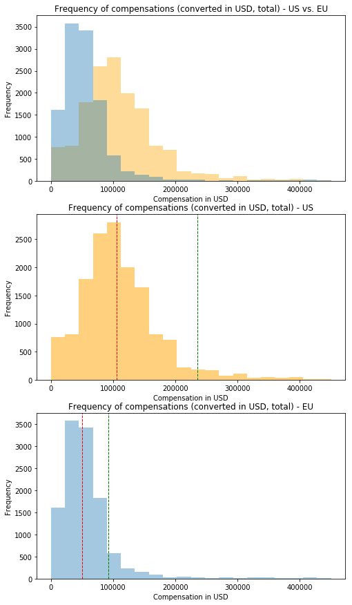

```python
fig, axs = plt.subplots(3, 1, figsize=(8,15))

axs[0].hist(data_us, bins=20, range=(0,450000), alpha=0.4, color='orange');
axs[0].hist(data_eu, bins=20, range=(0,450000), alpha=0.4);
axs[0].title.set_text('Frequency of compensations (converted in USD, total) - US vs. EU')

axs[1].hist(data_us, bins=20, range=(0,450000), alpha=0.5, color='orange');
axs[1].axvline(data_us.mean(), color='g', linestyle='dashed', linewidth=1);
axs[1].axvline(data_us.median(), color='r', linestyle='dashed', linewidth=1);
axs[1].title.set_text('Frequency of compensations (converted in USD, total) - US')

axs[2].hist(data_eu, bins=20, range=(0,450000), alpha=0.4);
axs[2].axvline(data_eu.mean(), color='g', linestyle='dashed', linewidth=1);
axs[2].axvline(data_eu.median(), color='r', linestyle='dashed', linewidth=1);
axs[2].title.set_text('Frequency of compensations (converted in USD, total) - EU');

axs[0].set_xlabel('Compensation in USD');
axs[1].set_xlabel('Compensation in USD');
axs[2].set_xlabel('Compensation in USD');
axs[0].set_ylabel('Frequency');
axs[1].set_ylabel('Frequency');
axs[2].set_ylabel('Frequency');
```

**3. What languages and databases do data professionals work with most? Which ones are in highest demand according to compensation?**

**Plots for all data professionals**

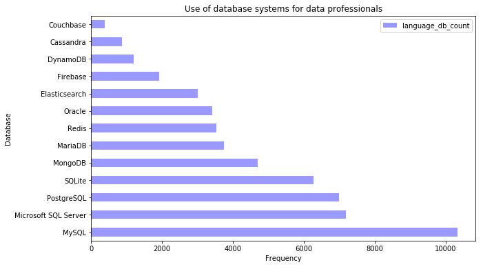

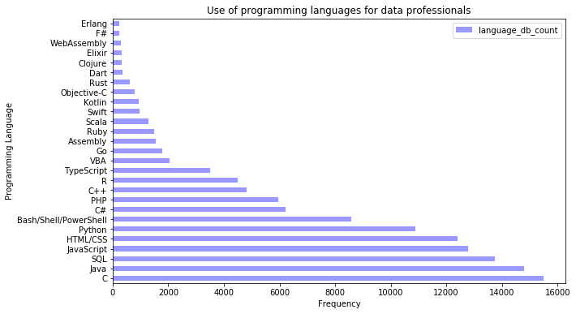

```python
# plot dbs used
df_data_guys_metrics[(df_data_guys_metrics['language_db'].isin(all_dbs_list))].\
                        sort_values('language_db_count', ascending=False).\
                        plot(x='language_db', y='language_db_count', kind='barh',
                             figsize=(10,6), color='b', alpha=0.4, title='Use of database systems for data professionals');

plt.xlabel("Frequency");
plt.ylabel("Database");

# plot languages used
df_data_guys_metrics[(df_data_guys_metrics['language_db'].isin(all_languages_list))].\
                        sort_values('language_db_count', ascending=False).\
                        plot(x='language_db', y='language_db_count', kind='barh',
                             figsize=(10,6), color='b', alpha=0.4, title='Use of programming languages for data professionals');
plt.xlabel("Frequency");
plt.ylabel("Programming Language");
```

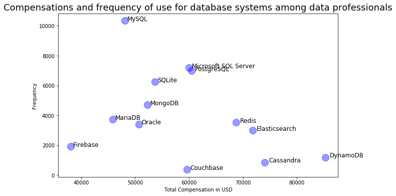

```python
x_db = df_data_guys_metrics['language_db_comp_median'][df_data_guys_metrics['language_db'].isin(all_dbs_list)].values
y_db = df_data_guys_metrics['language_db_count'][df_data_guys_metrics['language_db'].isin(all_dbs_list)].values

labels_db = df_data_guys_metrics['language_db'][df_data_guys_metrics['language_db'].isin(all_dbs_list)].values

plt.figure(figsize=(10,6))
plt.scatter(x_db, y_db, alpha=0.4, s=200, color='b')

for i, txt in enumerate(labels_db):
    plt.text(1.01*x_db[i], y_db[i], s=txt, fontsize=12)

plt.title("Compensations and frequency of use for database systems among data professionals", fontsize=18)
plt.xlabel("Total Compensation in USD")
plt.ylabel("Frequency")

plt.show()
```

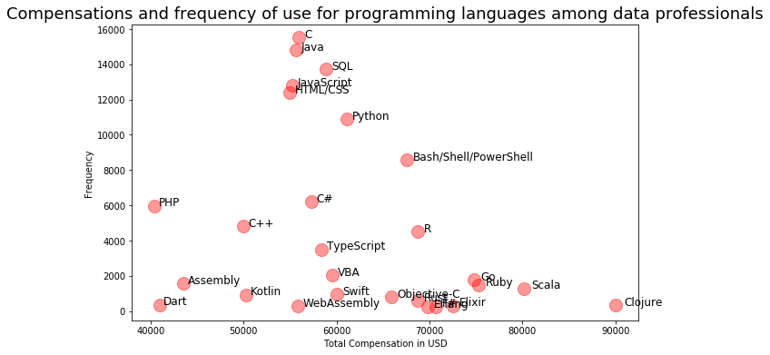

```python
x_language = df_data_guys_metrics['language_db_comp_median'][df_data_guys_metrics['language_db'].isin(all_languages_list)].values
y_language = df_data_guys_metrics['language_db_count'][df_data_guys_metrics['language_db'].isin(all_languages_list)].values

labels_language = df_data_guys_metrics['language_db'][df_data_guys_metrics['language_db'].isin(all_languages_list)].values

plt.figure(figsize=(10,6))
plt.scatter(x_language, y_language, alpha=0.4, s=200, color='r')

for i, txt in enumerate(labels_language):
    plt.text(1.01*x_language[i], y_language[i], s=txt, fontsize=12)

plt.title("Compensations and frequency of use for programming languages among data professionals", fontsize=18)
plt.xlabel("Total Compensation in USD")
plt.ylabel("Frequency")

plt.show()
```

**Plots for specific data professionals**

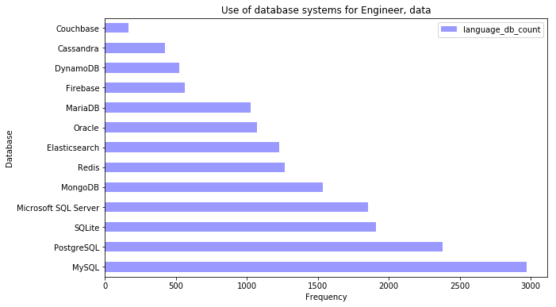

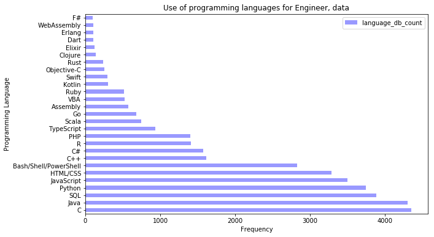

```python
# select one of the jobs:
# ['Data or business analyst', 'Data scientist or machine learning specialist',
# 'Database administrator', 'Engineer, data']

job = 'Engineer, data'
df_data_professional = plots_for_data_professionals(job)
```

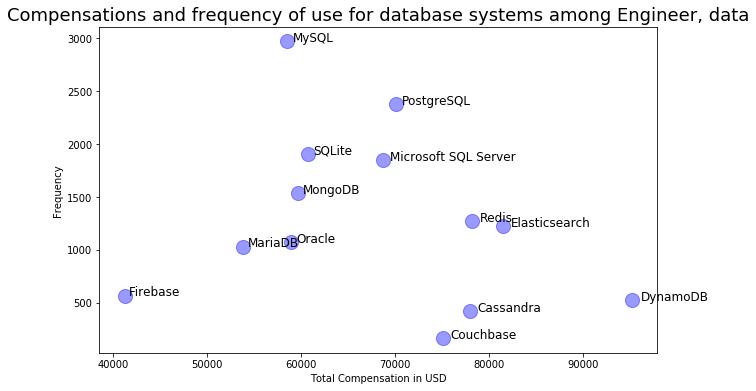

```python
x_db = df_data_professional['language_db_comp_median'][df_data_professional['language_db'].isin(all_dbs_list)].values
y_db = df_data_professional['language_db_count'][df_data_professional['language_db'].isin(all_dbs_list)].values

labels_db = df_data_professional['language_db'][df_data_professional['language_db'].isin(all_dbs_list)].values

plt.figure(figsize=(10,6))
plt.scatter(x_db, y_db, alpha=0.4, s=200, color='b')

for i, txt in enumerate(labels_db):
    plt.text(1.01*x_db[i], y_db[i], s=txt, fontsize=12)

plt.title("Compensations and frequency of use for database systems among "+job, fontsize=18)
plt.xlabel("Total Compensation in USD")
plt.ylabel("Frequency")

plt.show()
```

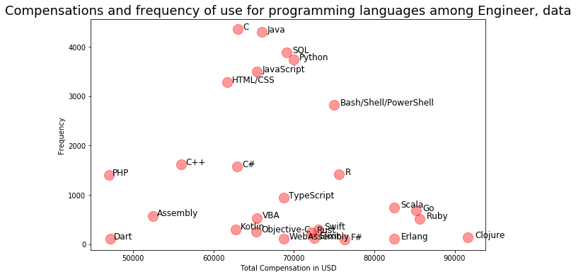

```python
x_language = df_data_professional['language_db_comp_median'][df_data_professional['language_db'].isin(all_languages_list)].values
y_language = df_data_professional['language_db_count'][df_data_professional['language_db'].isin(all_languages_list)].values

labels_language = df_data_professional['language_db'][df_data_professional['language_db'].isin(all_languages_list)].values

plt.figure(figsize=(10,6))
plt.scatter(x_language, y_language, alpha=0.4, s=200, color='r')

for i, txt in enumerate(labels_language):
    plt.text(1.01*x_language[i], y_language[i], s=txt, fontsize=12)

plt.title("Compensations and frequency of use for programming languages among "+job, fontsize=18)
plt.xlabel("Total Compensation in USD")
plt.ylabel("Frequency")

plt.show()
```

```python
from subprocess import call
call(['python', '-m', 'nbconvert', 'ds_blog_post_so_data_v2.ipynb'])
```